# Exploratory Data Analysis Report

Report by dlookr package

2022-08-29

# 1 Introduction

The EDA Report provides exploratory data analysis information on objects that inherit data.frame and data.frame.

## 1.1 Information of Dataset

The dataset that generated the EDA Report is an **‘data.frame’** object. It consists of **3,832,164 observations** and **40 variables**.

## 1.2 Information of Variables

The variable information of the data set that generated the EDA Report is shown in the following table.:

Information of Variables

| variables | types | missing_count | missing_percent | unique_count | unique_rate |
| --- | --- | --- | --- | --- | --- |
| RESP_ID | numeric | 0 | 0.00 | 3832164 | 1.000 |
| RESP_SURVEY_ID | numeric | 0 | 0.00 | 20933 | 0.005 |
| RESP_Q_ID | numeric | 0 | 0.00 | 347 | 0.000 |
| RESP_POINTS | numeric | 976723 | 25.49 | 9 | 0.000 |
| RESP_COMMENT | character | 3534306 | 92.23 | 276621 | 0.072 |
| RESP_MAJORS | character | 2218526 | 57.89 | 3233 | 0.001 |
| RESP_IMAGE | character | 3816775 | 99.60 | 1661 | 0.000 |
| RESP_TEACHER_ID | character | 3107897 | 81.10 | 4365 | 0.001 |
| RESP_TEACHER_INCORRECT | numeric | 3731359 | 97.37 | 2 | 0.000 |
| RESP_DATE | POSIXct | 0 | 0.00 | 1370 | 0.000 |
| RESP_COURSE | character | 20227 | 0.53 | 660 | 0.000 |
| RESP_FIELDOFSTUDY | character | 25769 | 0.67 | 81 | 0.000 |
| RESP_IMPORT_BATCH | numeric | 3807017 | 99.34 | 307 | 0.000 |
| RESP_FORM_KEY | character | 0 | 0.00 | 421264 | 0.110 |
| RESP_DMG_GENDER | character | 604843 | 15.78 | 5 | 0.000 |
| RESP_DMG_AGE | numeric | 201801 | 5.27 | 66 | 0.000 |
| RESP_DMG_INDIGENOUS | character | 1098453 | 28.66 | 8 | 0.000 |
| RESP_DMG_COB | character | 1098453 | 28.66 | 179 | 0.000 |
| RESP_DMG_CITIZEN | character | 1098453 | 28.66 | 8 | 0.000 |
| RESP_DMG_LANGUAGE | character | 1098453 | 28.66 | 165 | 0.000 |
| RESP_DMG_HOME | character | 1098453 | 28.66 | 826 | 0.000 |
| RESP_DMG_TERM | character | 1098453 | 28.66 | 811 | 0.000 |
| RESP_DMG_SES | character | 1098453 | 28.66 | 6 | 0.000 |
| RESP_DMG_BASIS_OF_ADM | numeric | 206940 | 5.40 | 20 | 0.000 |
| RESP_DMG_LIABILITY_CAT | character | 1098586 | 28.67 | 8 | 0.000 |
| RESP_DMG_INT_ATTEND_TYPE | character | 1098586 | 28.67 | 3 | 0.000 |
| RESP_DMG_COMMENCING | character | 1098586 | 28.67 | 3 | 0.000 |
| RESP_DMG_COURSE_CAMPUS | character | 1098586 | 28.67 | 7 | 0.000 |
| RESP_DMG_SP_ADM_SCHEME | character | 3539819 | 92.37 | 5 | 0.000 |
| RESP_DMG_SCHOLARSHIP | logical | 3825490 | 99.83 | 2 | 0.000 |
| RESP_DMG_MODE_OF_ATTEND | character | 1098586 | 28.67 | 5 | 0.000 |
| RESP_DMG_SCHOOL_LEAVER | character | 3823521 | 99.77 | 3 | 0.000 |
| RESP_DMG_UAC_PREFERENCE | numeric | 202041 | 5.27 | 12 | 0.000 |
| RESP_DMG_ATAR_ON_ADM | numeric | 3427226 | 89.43 | 333 | 0.000 |
| RESP_DMG_PREVIOUS_CREDIT | numeric | 202041 | 5.27 | 125 | 0.000 |
| RESP_DMG_PREVIOUS_INSTI | character | 3031211 | 79.10 | 178 | 0.000 |
| RESP_DMG_STUDENT_COMM_YR | character | 1098586 | 28.67 | 7 | 0.000 |
| RESP_DMG_GRAD_LVL | character | 1098586 | 28.67 | 5 | 0.000 |
| RESP_STUDENT_ID_HASH | character | 922039 | 24.06 | 53367 | 0.014 |
| RESP_COMMENT_HIDDEN | numeric | 0 | 0.00 | 2 | 0.000 |

The target variable of the data is **‘NULL’**, and the data type of the variable is **NULL(You did not specify a target variable)**.

## 1.3 About EDA Report

EDA reports provide information and visualization results that support the EDA process. In particular, it provides a variety of information to understand the relationship between the target variable and the rest of the variables of interest.

# 2 Univariate Analysis

## 2.1 Descriptive Statistics

edaData  
40 Variables 3832164 Observations

RESP_ID

```
        n  missing distinct     Info     Mean      Gmd      .05      .10      .25
  3832164        0  3832164        1 18327173  2925479 14455337 14809773 16175823
      .50      .75      .90      .95
 18320453 20530326 21858266 22305437
```

lowest : 13926596 13926597 13926598 13926599 13926600 , highest: 22683745 22683746 22683747 22683748 22683749

RESP_SURVEY_ID

```
        n  missing distinct     Info     Mean      Gmd      .05      .10      .25
  3832164        0    20933        1   256839    60244   182690   186617   214605
      .50      .75      .90      .95
   258262   300757   332272   344570
```

lowest : 163402 163403 163404 163405 163406 , highest: 350486 350501 350512 350533 350626

RESP_Q_ID

| n | missing | distinct | Info | Mean | Gmd | .05 | .10 | .25 | .50 | .75 | .90 | .95 |
| --- | --- | --- | --- | --- | --- | --- | --- | --- | --- | --- | --- | --- |
| 3832164 | 0 | 347 | 0.987 | 3040 | 1022 | 1053 | 1053 | 3131 | 3708 | 3712 | 3724 | 3725 |

lowest : 5 6 106 112 122 , highest: 4043 4044 4045 4046 4047

RESP_POINTS

| n | missing | distinct | Info | Mean | Gmd |
| --- | --- | --- | --- | --- | --- |
| 2855441 | 976723 | 8 | 0.865 | 4.126 | 0.9721 |

lowest : 0 1 2 3 4 , highest: 3 4 5 6 7

```
 Value            0       1       2       3       4       5       6       7
 Frequency       50   72060  129586  339353 1139024 1175341       8      19
 Proportion   0.000   0.025   0.045   0.119   0.399   0.412   0.000   0.000
```

RESP_COMMENT

| n | missing | distinct |
| --- | --- | --- |
| 297858 | 3534306 | 276620 |

| lowest : | _ Hayley is very helpful in assisting students in their work and clarifying questions about assessments in a clear and concise manner ( whether in the tutorial or via email ) - Engages with students a… | - | - 6 weeks at the start of semester dedicated to CN, 6 weeks at the end dedicated to your group assignment - It's quite frustrating that we've only received our results for one of our CN stories over t… | - Albie was a good teacher, he was keen, engaging and really made an effort to engage with the class - He used interesting examples and tied them to both the modern world, current examples, and histor… | - I found the Friday lectures very enriching and valuable as they took a more multidisciplinary approach towards visual communications and introduced me to a number of key movements and creative metho… |
| --- | --- | --- | --- | --- | --- |
| highest: | Zybook textbook was very useful. Raymond was funny in his lectures. | Zybook was really boring compared to in-class learning, and... Don't. Make it. Group based. Or if you do give an element of group learning, make it so that 70% of your mark isn't based on it. *Serious… | Zybooks had just too much content and it made it hard to pick up on much | Zybooks used to learn MATLAB was... sometimes good and sometimes not. It was good to learn the basics of how to use it however it gave extremely specific examples of certain uses. Could not fully use … | Zybooks was really good! |

RESP_MAJORS

| n | missing | distinct |
| --- | --- | --- |
| 1613638 | 2218526 | 3232 |

| lowest : | MAJ01079 | MAJ01079,MAJ01081,MAJ01114 | MAJ01079,MAJ01081,MAJ01114,MAJ09443 | MAJ01079,MAJ01085 | MAJ01079,MAJ01114 |
| --- | --- | --- | --- | --- | --- |
| highest: | MAJ10053,MAJ03445 | MAJ10053,MAJ03519 | MAJ10054 | MAJ10055 | MAJ10057 |

RESP_IMAGE

| n | missing | distinct |
| --- | --- | --- |
| 15389 | 3816775 | 1660 |

| lowest : | 00QUYY220000.tct | 01H9HEJZ0000.tct | 01WODZGP0000.tct | 02DYIU7Y0000.tct | 02IEMHAJ0000.tct |
| --- | --- | --- | --- | --- | --- |
| highest: | ZYG3GB1Q0000.tct | ZYVYRKSM0000.tct | ZZD16GOE0000.tct | ZZII9L7L0000.tct | ZZJTTKGE0000.tct |

RESP_TEACHER_ID

| n | missing | distinct |
| --- | --- | --- |
| 724267 | 3107897 | 4364 |

| lowest : | 5 | 5.A | 5.A]Jd | 5.A^Bd | 5.ARNg |
| --- | --- | --- | --- | --- | --- |
| highest: | lNCAXO | lNCCXP | lNCERI | lNCGRM | lNCHTN |

RESP_TEACHER_INCORRECT

| n | missing | distinct | Info | Mean | Gmd |
| --- | --- | --- | --- | --- | --- |
| 100805 | 3731359 | 1 | 0 | 1 | 0 |

```
 Value           1
 Frequency  100805
 Proportion      1
```

RESP_DATE

```
          n    missing   distinct       Info       Mean        Gmd        .05
    3832164          0       1370          1 2019-05-16   49791882 2017-06-04
        .10        .25        .50        .75        .90        .95
 2017-06-16 2018-05-28 2019-05-31 2020-06-05 2021-05-18 2021-10-21
```

| lowest : | 2017-02-08 | 2017-02-20 | 2017-02-21 | 2017-02-24 | 2017-02-25 |
| --- | --- | --- | --- | --- | --- |
| highest: | 2022-02-16 | 2022-02-17 | 2022-02-18 | 2022-02-19 | 2022-02-20 |

RESP_COURSE

| n | missing | distinct |
| --- | --- | --- |
| 3811937 | 20227 | 659 |

lowest : C00100 C00102 C02018 C02019 C02024 , highest: C42016 C50002 C50006 C50007 C91371

RESP_FIELDOFSTUDY

| n | missing | distinct |
| --- | --- | --- |
| 3806395 | 25769 | 80 |

lowest : 0 000000 020201 020301 020401 , highest: 90309 90499 90505 FALSE TRUE

RESP_IMPORT_BATCH

| n | missing | distinct | Info | Mean | Gmd | .05 | .10 | .25 | .50 | .75 | .90 | .95 |
| --- | --- | --- | --- | --- | --- | --- | --- | --- | --- | --- | --- | --- |
| 25147 | 3807017 | 306 | 0.994 | 253.9 | 265.1 | 1 | 1 | 54 | 124 | 469 | 626 | 628 |

lowest : 1 2 3 4 5 , highest: 626 628 629 630 631

RESP_FORM_KEY

| n | missing | distinct |
| --- | --- | --- |
| 3832164 | 0 | 421264 |

| lowest : | 00001a10ffb875ab050283554dfaa065 | 000036bdf8a6e7c470373ca1d400262b | 00007f3092d1f00091f5708256b23497 | 0000a0b9507ae68983de026b405fb9c6 | 0000b519f6e5dd07614df9f8d9651cf4 |
| --- | --- | --- | --- | --- | --- |
| highest: | ffffb59e03e703845eaf0bcaf44f1b2e | ffffe12c5e8664ba92d1298c40b5699e | ffffe4ef573da2b2e0e7b33351780192 | ffffe824552da16325f995b9caead343 | fffffc461dec8707fc0f6bdab41eb6f0 |

RESP_DMG_GENDER

| n | missing | distinct |
| --- | --- | --- |
| 3227321 | 604843 | 4 |

```
 Value            F   FALSE       M       X
 Frequency  1515811  493649 1216312    1549
 Proportion   0.470   0.153   0.377   0.000
```

RESP_DMG_AGE

| n | missing | distinct | Info | Mean | Gmd | .05 | .10 | .25 | .50 | .75 | .90 | .95 |
| --- | --- | --- | --- | --- | --- | --- | --- | --- | --- | --- | --- | --- |
| 3630363 | 201801 | 65 | 0.98 | 17.95 | 11.36 | 1 | 1 | 18 | 21 | 23 | 27 | 32 |

lowest : 1 15 17 18 19 , highest: 76 77 78 79 80

RESP_DMG_INDIGENOUS

| n | missing | distinct |
| --- | --- | --- |
| 2733711 | 1098453 | 7 |

| lowest : | Aboriginal | Both Abor and TSI | Both Aboriginal and Torres Strait Island | No | Not Answered |
| --- | --- | --- | --- | --- | --- |
| highest: | Both Aboriginal and Torres Strait Island | No | Not Answered | Not entered | Torres Strait Islander |

RESP_DMG_COB

| n | missing | distinct |
| --- | --- | --- |
| 2733711 | 1098453 | 178 |

| lowest : | Afghanistan | Albania | Algeria | Argentina | Armenia |
| --- | --- | --- | --- | --- | --- |
| highest: | Vietnam | Wales | Yemen | Zambia | Zimbabwe |

RESP_DMG_CITIZEN

| n | missing | distinct |
| --- | --- | --- |
| 2733711 | 1098453 | 7 |

| lowest : | Australian | New Zealander | Not entered | Overseas Student Residing Overseas | Permanent Humanitarian Visa |
| --- | --- | --- | --- | --- | --- |
| highest: | Not entered | Overseas Student Residing Overseas | Permanent Humanitarian Visa | Permanent Resident (excl Humanitarian) | Temporary Entry Permit |

RESP_DMG_LANGUAGE

| n | missing | distinct |
| --- | --- | --- |
| 2733711 | 1098453 | 164 |

| lowest : | Aboriginal English, so described | Acholi | African Languages (Excluding North Afric | Afrikaans | Akan |
| --- | --- | --- | --- | --- | --- |
| highest: | Uzbeck | Vietnamese | Wu | Yoruba | Yumplatok (Torres Strait Creole) |

RESP_DMG_HOME

| n | missing | distinct |
| --- | --- | --- |
| 2733711 | 1098453 | 825 |

lowest : A0810 A0812 A0820 A0828 A0830 , highest: A7054 A7248 A7249 A7250 UNKN

RESP_DMG_TERM

| n | missing | distinct |
| --- | --- | --- |
| 2733711 | 1098453 | 810 |

lowest : A0810 A0812 A0820 A0828 A0830 , highest: A7054 A7155 A7248 A7304 UNKN

RESP_DMG_SES

| n | missing | distinct |
| --- | --- | --- |
| 2733711 | 1098453 | 5 |

lowest : h High l m NA , highest: h High l m NA

```
 Value            h    High       l       m      NA
 Frequency  1382199     133  213970  931886  205523
 Proportion   0.506   0.000   0.078   0.341   0.075
```

RESP_DMG_BASIS_OF_ADM

| n | missing | distinct | Info | Mean | Gmd | .05 | .10 | .25 | .50 | .75 | .90 | .95 |
| --- | --- | --- | --- | --- | --- | --- | --- | --- | --- | --- | --- | --- |
| 3625224 | 206940 | 19 | 0.964 | 14.43 | 12.15 | 1 | 1 | 11 | 12 | 18 | 31 | 32 |

lowest : 1 11 12 13 14 , highest: 32 34 41 43 62

```
 Value           1     11     12     13     14     15     16     18     19     20
 Frequency  895938 750418 263048      9 787696  10759   4952   9683   5624    237
 Proportion  0.247  0.207  0.073  0.000  0.217  0.003  0.001  0.003  0.002  0.000

 Value          22     23     29     31     32     34     41     43     62
 Frequency    9724  61808 270562 308754  87973  10693 137016   2259   8071
 Proportion  0.003  0.017  0.075  0.085  0.024  0.003  0.038  0.001  0.002
```

RESP_DMG_LIABILITY_CAT

| n | missing | distinct |
| --- | --- | --- |
| 2733578 | 1098586 | 7 |

lowest : DF HL IF LE NW , highest: IF LE NW RT UF

```
 Value           DF      HL      IF      LE      NW      RT      UF
 Frequency   237489 1555421  936661     412     530    3014      51
 Proportion   0.087   0.569   0.343   0.000   0.000   0.001   0.000
```

RESP_DMG_INT_ATTEND_TYPE

| n | missing | distinct |
| --- | --- | --- |
| 2733578 | 1098586 | 2 |

```
 Value           FT      PT
 Frequency  2632845  100733
 Proportion   0.963   0.037
```

RESP_DMG_COMMENCING

| n | missing | distinct |
| --- | --- | --- |
| 2733578 | 1098586 | 2 |

```
 Value         Comm    Cont
 Frequency  1082037 1651541
 Proportion   0.396   0.604
```

RESP_DMG_COURSE_CAMPUS

| n | missing | distinct |
| --- | --- | --- |
| 2733578 | 1098586 | 6 |

| lowest : | China | City campus | Hong Kong | Kuring-gai campus | Moore Park Precinct |
| --- | --- | --- | --- | --- | --- |
| highest: | City campus | Hong Kong | Kuring-gai campus | Moore Park Precinct | Online campus |

```
 Value                    China         City campus           Hong Kong
 Frequency                 2973             2682478                1115
 Proportion               0.001               0.981               0.000

 Value        Kuring-gai campus Moore Park Precinct       Online campus
 Frequency                 6247               36125                4640
 Proportion               0.002               0.013               0.002
```

RESP_DMG_SP_ADM_SCHEME

| n | missing | distinct |
| --- | --- | --- |
| 292345 | 3539819 | 4 |

```
 Value       TSDIS  TSEAP  TSINS  TSREF
 Frequency      71  11131 272368   8775
 Proportion  0.000  0.038  0.932  0.030
```

RESP_DMG_SCHOLARSHIP

| n | missing | distinct | value |
| --- | --- | --- | --- |
| 6674 | 3825490 | 1 | TRUE |

```
 Value      TRUE
 Frequency  6674
 Proportion    1
```

RESP_DMG_MODE_OF_ATTEND

| n | missing | distinct |
| --- | --- | --- |
| 2733578 | 1098586 | 4 |

```
 Value          BLC     EXT     INT     OLN
 Frequency    48394   25692 2654852    4640
 Proportion   0.018   0.009   0.971   0.002
```

RESP_DMG_SCHOOL_LEAVER

| n | missing | distinct |
| --- | --- | --- |
| 8643 | 3823521 | 2 |

```
 Value        CSL  CSLX
 Frequency    848  7795
 Proportion 0.098 0.902
```

RESP_DMG_UAC_PREFERENCE

| n | missing | distinct | Info | Mean | Gmd | .05 | .10 | .25 | .50 | .75 | .90 | .95 |
| --- | --- | --- | --- | --- | --- | --- | --- | --- | --- | --- | --- | --- |
| 3630123 | 202041 | 11 | 0.765 | 0.9373 | 0.7504 | 0 | 0 | 0 | 1 | 1 | 2 | 2 |

lowest : 0 1 2 3 4 , highest: 6 7 8 9 99

```
 Value            0       1       2       3       4       5       6       7       8
 Frequency   959127 2175652  338016  105488   34216   12817    2815    1156     527
 Proportion   0.264   0.599   0.093   0.029   0.009   0.004   0.001   0.000   0.000

 Value            9      99
 Frequency      293      16
 Proportion   0.000   0.000
```

RESP_DMG_ATAR_ON_ADM

| n | missing | distinct | Info | Mean | Gmd | .05 | .10 | .25 | .50 | .75 | .90 | .95 |
| --- | --- | --- | --- | --- | --- | --- | --- | --- | --- | --- | --- | --- |
| 404938 | 3427226 | 332 | 0.468 | 4.623 | 7.528 | 0 | 0 | 1 | 1 | 1 | 1 | 1 |

lowest : 0.00 1.00 69.15 69.50 70.20 , highest: 99.95 99.95 191.00 192.00 194.00

```
 Value           0     70     72     74     76     78     80     82     84     86
 Frequency  388576    323      6    508    407    563    919    559   1383   1167
 Proportion  0.960  0.001  0.000  0.001  0.001  0.001  0.002  0.001  0.003  0.003

 Value          88     90     92     94     96     98    100    192    194
 Frequency    1125   1134   1236   1294   1621   1246   2087    635    149
 Proportion  0.003  0.003  0.003  0.003  0.004  0.003  0.005  0.002  0.000
```

For the frequency table, variable is rounded to the nearest 2

RESP_DMG_PREVIOUS_CREDIT

| n | missing | distinct | Info | Mean | Gmd | .05 | .10 | .25 | .50 | .75 | .90 | .95 |
| --- | --- | --- | --- | --- | --- | --- | --- | --- | --- | --- | --- | --- |
| 3630123 | 202041 | 124 | 0.239 | 2.646 | 5.065 | 0 | 0 | 0 | 0 | 0 | 0 | 24 |

lowest : 0 1 3 6 8 , highest: 201 204 208 213 216

RESP_DMG_PREVIOUS_INSTI

| n | missing | distinct |
| --- | --- | --- |
| 800953 | 3031211 | 177 |

| lowest : | Aalborg Universitet | Academy of Information Technology Pty Lt | ACT Institute of TAFE | AFL Sports Ready | Albury Seventh Day Adventist School |
| --- | --- | --- | --- | --- | --- |
| highest: | Wentworth Institute of Technology | Western Sydney Institute of TAFE (Nepean | Western Sydney University | Wetherill Park College of TAFE | William Angliss Institute of TAFE |

RESP_DMG_STUDENT_COMM_YR

| n | missing | distinct |
| --- | --- | --- |
| 2733578 | 1098586 | 6 |

lowest : 1st Year 2nd Year 3rd Year 4th Year 5th Year , highest: 2nd Year 3rd Year 4th Year 5th Year 6th Year

```
 Value      1st Year 2nd Year 3rd Year 4th Year 5th Year 6th Year
 Frequency   1504452   709692   374003   102883    41867      681
 Proportion    0.550    0.260    0.137    0.038    0.015    0.000
```

RESP_DMG_GRAD_LVL

| n | missing | distinct |
| --- | --- | --- |
| 2733578 | 1098586 | 4 |

```
 Value            N       O      PG      UG
 Frequency    15350      33  684413 2033782
 Proportion   0.006   0.000   0.250   0.744
```

RESP_STUDENT_ID_HASH

| n | missing | distinct |
| --- | --- | --- |
| 2910125 | 922039 | 53366 |

| lowest : | MDAwMDAxMTM= | MDAwMDk2Mjk= | MDAwMjQ0NDI= | MDAwMTk4MTA= | MDAwMzgyNDA= |
| --- | --- | --- | --- | --- | --- |
| highest: | OTYxMjQ4NzA= | OTYxMTU4MjE= | OTYxMTY1NTc= | OTYxMzA2MTg= | OTYxMzA5NTA= |

RESP_COMMENT_HIDDEN

| n | missing | distinct | Info | Sum | Mean | Gmd |
| --- | --- | --- | --- | --- | --- | --- |
| 3832164 | 0 | 2 | 0 | 9 | 2.349e-06 | 4.697e-06 |

## 2.2 Normality Test of Numerical Variables

### 2.2.1 Statistics and Visualization of (Sample) Data

**[ RESP_ID ]**

normality test : Shapiro-Wilk normality test

```
 statistic : 0.94816,  p-value : 8.48768E-39
```

skewness and kurtosis

| type | skewness | kurtosis |
| --- | --- | --- |
| original | 0.0469793 | 1.749065 |
| log transformation | -0.1119915 | 1.773508 |
| sqrt transformation | -0.0320496 | 1.754308 |

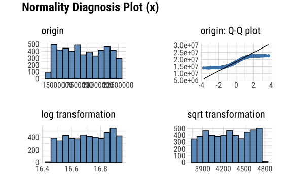

**[ RESP_SURVEY_ID ]**

normality test : Shapiro-Wilk normality test

```
 statistic : 0.93977,  p-value : 4.62736E-41
```

skewness and kurtosis

| type | skewness | kurtosis |
| --- | --- | --- |
| original | 0.1524858 | 1.747824 |
| log transformation | -0.0776304 | 1.746527 |
| sqrt transformation | 0.0384158 | 1.732404 |

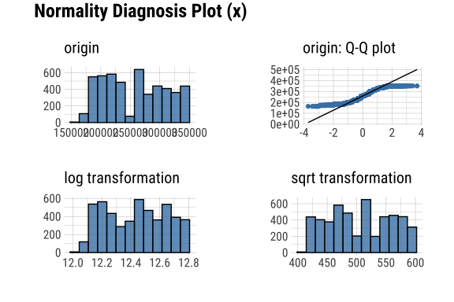

**[ RESP_Q_ID ]**

normality test : Shapiro-Wilk normality test

```
 statistic : 0.62983,  p-value : 8.76737E-74
```

skewness and kurtosis

| type | skewness | kurtosis |
| --- | --- | --- |
| original | -1.203586 | 2.604976 |
| log transformation | -1.645396 | 5.423015 |
| sqrt transformation | -1.297134 | 2.975013 |

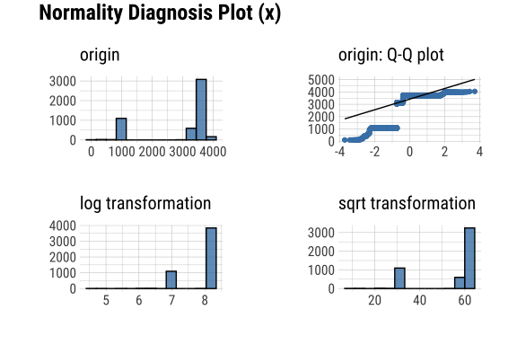

**[ RESP_POINTS ]**

normality test : Shapiro-Wilk normality test

```
 statistic : 0.78612,  p-value : 7.30676E-63
```

skewness and kurtosis

| type | skewness | kurtosis |
| --- | --- | --- |
| original | -1.260288 | 4.373310 |
| log transformation | -2.423430 | 9.889181 |
| sqrt transformation | -1.764784 | 6.466314 |

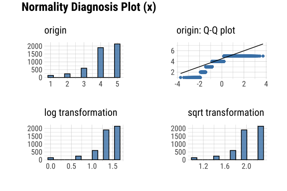

**[ RESP_IMPORT_BATCH ]**

normality test : Shapiro-Wilk normality test

```
 statistic : 0.80673,  p-value : 6.05893E-61
```

skewness and kurtosis

| type | skewness | kurtosis |
| --- | --- | --- |
| original | 0.3966982 | 1.418744 |
| log transformation | -0.9878033 | 2.606833 |
| sqrt transformation | 0.0268757 | 1.459346 |

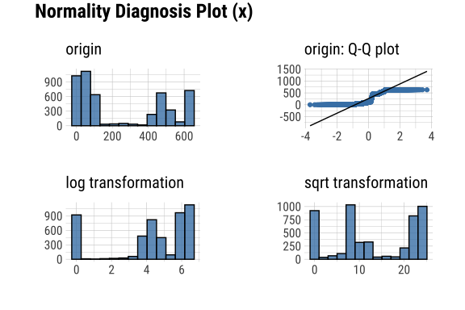

**[ RESP_DMG_AGE ]**

normality test : Shapiro-Wilk normality test

```
 statistic : 0.83288,  p-value : 3.03854E-58
```

skewness and kurtosis

| type | skewness | kurtosis |
| --- | --- | --- |
| original | -0.1047842 | 3.537818 |
| log transformation | -1.1075319 | 2.333992 |
| sqrt transformation | -0.8603256 | 2.374324 |

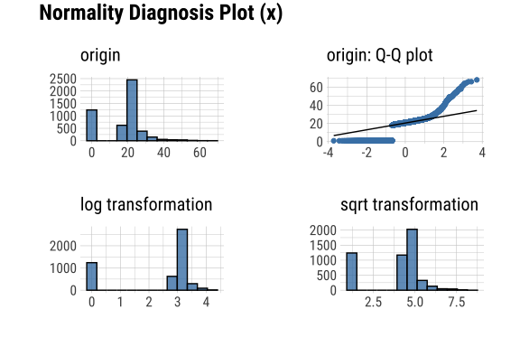

**[ RESP_DMG_BASIS_OF_ADM ]**

normality test : Shapiro-Wilk normality test

```
 statistic : 0.86802,  p-value : 5.39671E-54
```

skewness and kurtosis

| type | skewness | kurtosis |
| --- | --- | --- |
| original | 0.7717479 | 3.102202 |
| log transformation | -0.8212997 | 2.164098 |
| sqrt transformation | -0.1158416 | 2.159953 |

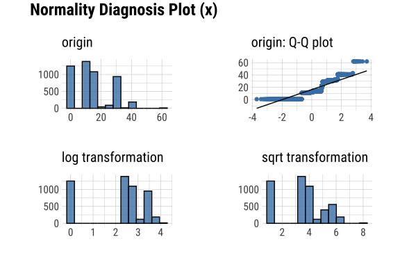

**[ RESP_DMG_UAC_PREFERENCE ]**

normality test : Shapiro-Wilk normality test

```
 statistic : 0.74386,  p-value : 2.36032E-66
```

skewness and kurtosis

| type | skewness | kurtosis |
| --- | --- | --- |
| original | 1.6521911 | 9.307826 |
| log+1 transformation | -0.0872421 | 2.900084 |
| sqrt transformation | -0.4530269 | 2.522075 |

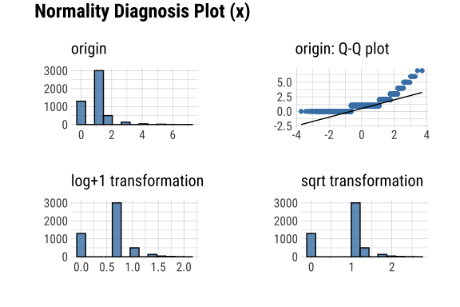

**[ RESP_DMG_ATAR_ON_ADM ]**

normality test : Shapiro-Wilk normality test

```
 statistic : 0.20615,  p-value : 1.83308E-90
```

skewness and kurtosis

| type | skewness | kurtosis |
| --- | --- | --- |
| original | 5.175163 | 31.21348 |
| log+1 transformation | 3.978048 | 19.31178 |
| sqrt transformation | 4.461357 | 22.46022 |

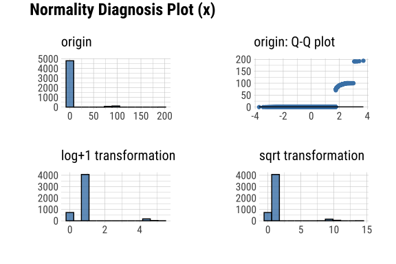

**[ RESP_DMG_PREVIOUS_CREDIT ]**

normality test : Shapiro-Wilk normality test

```
 statistic : 0.21629,  p-value : 3.61889E-90
```

skewness and kurtosis

| type | skewness | kurtosis |
| --- | --- | --- |
| original | 6.543652 | 56.12805 |
| log+1 transformation | 3.826760 | 16.39046 |
| sqrt transformation | 4.373288 | 22.55897 |

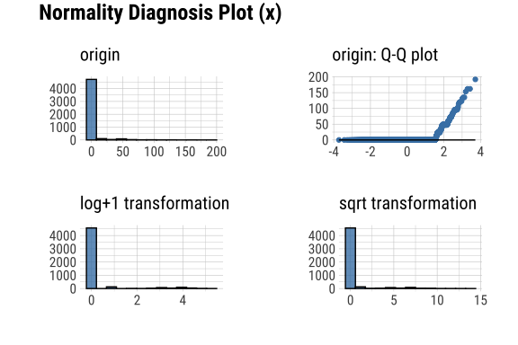

**[ RESP_COMMENT_HIDDEN ]**

normality test : Shapiro-Wilk normality test

all ‘x’ values are identical

# 3 Relationship Between Variables

## 3.1 Correlation Coefficient

### 3.1.1 Correlation Coefficient by Variable Combination

Table of correlation coefficients (0.5 or more)

| Variable1 | Variable2 | Correlation Coefficient |
| --- | --- | --- |
| RESP_SURVEY_ID | RESP_ID | 0.9937980 |
| RESP_DMG_AGE | RESP_ID | 0.6614415 |
| RESP_IMPORT_BATCH | RESP_ID | -0.6579894 |
| RESP_IMPORT_BATCH | RESP_SURVEY_ID | -0.6362225 |
| RESP_DMG_AGE | RESP_SURVEY_ID | 0.6358026 |
| RESP_DMG_BASIS_OF_ADM | RESP_ID | 0.5897012 |
| RESP_DMG_BASIS_OF_ADM | RESP_SURVEY_ID | 0.5754826 |
| RESP_DMG_BASIS_OF_ADM | RESP_DMG_AGE | 0.5268741 |

### 3.1.2 Correlation Plot of Numerical Variables

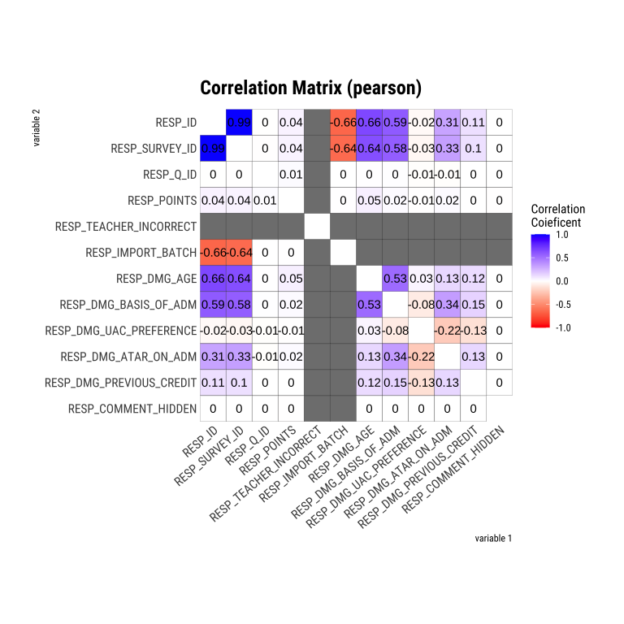

# 4 Target based Analysis

## 4.1 Grouped Descriptive Statistics

### 4.1.1 Grouped Numerical Variables

There is no target variable.

### 4.1.2 Grouped Categorical Variables

There is no target variable.

## 4.2 Grouped Relationship Between Variables

### 4.2.1 Grouped Correlation Coefficient

```
There is no target variable.
```

### 4.2.2 Grouped Correlation Plot of Numerical Variables

```
There is no target variable.
```